# MasterControl — Lead Scoring & Conversion Optimization

A Visual Report on Feature Engineering, Model Selection & Business Impact

Author

Thomas Beck · Max Ridgeway · Astha KC

Published

January 1, 2026

# Business Problem

MasterControl sells quality management software to regulated industries through two product lines: **Mx** (manufacturing execution) and **Qx** (quality management). Leads enter the pipeline as Qualified Activity Leads (QALs) and progress through stages — Disqualified, Recycled, SQL, SQO, or Won.

The core challenge is **conversion efficiency**. Mx converts at roughly 12.7% versus 19.7% for Qx — a 7 percentage-point gap. With a $50 cost per sales call and $6,000 value per SQL conversion, the ability to identify which leads are most likely to convert has direct revenue impact.

# Methodology

The CRISP-DM framework structures the analysis:

# Data Preparation & Feature Engineering

```
**Dataset Overview**

| Metric              | Value                       |
|:--------------------|:----------------------------|
| Total Leads         | 16,815                      |
| Target Rate (SQL+)  | 17.9%                       |
| Mx Leads            | 4,239 (12.6% conv.)         |
| Qx Leads            | 12,547 (19.7% conv.)        |
| Decision Makers     | 3,066 (18.2%)               |
| Features Engineered | 6 core + 8 interaction/flag |
```

## Understanding the Data at a Glance

Before diving into modeling, the visualizations below paint a picture of the raw conversion landscape — where leads come from, who they are, and how these attributes relate to conversion.

### Target Distribution & Product Segment Gap

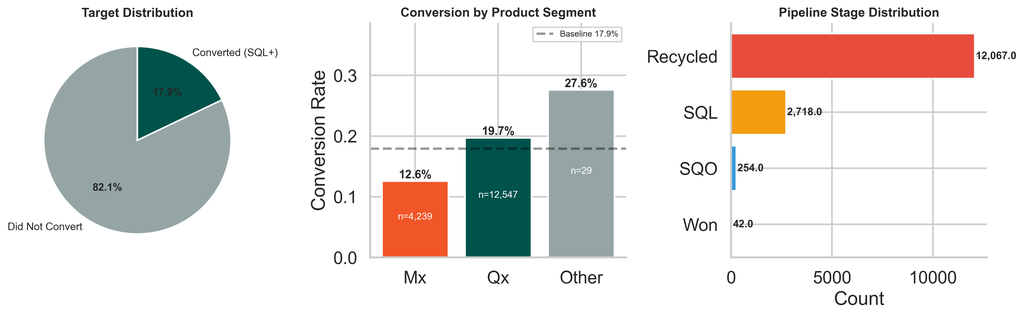

### Channel Tier Conversion Rates

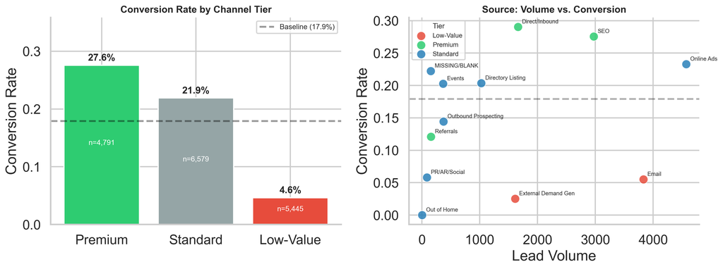

### Seniority & Function Heatmap

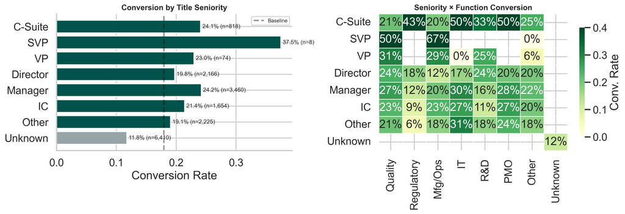

### Engineered Feature Distributions

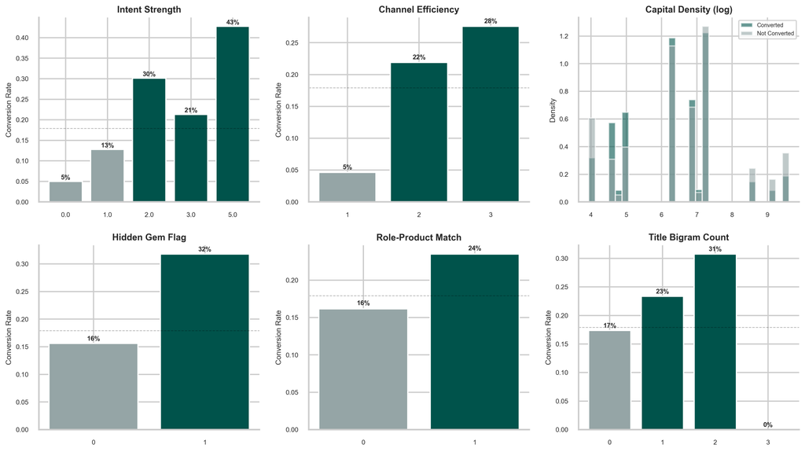

### Feature Correlation Matrix

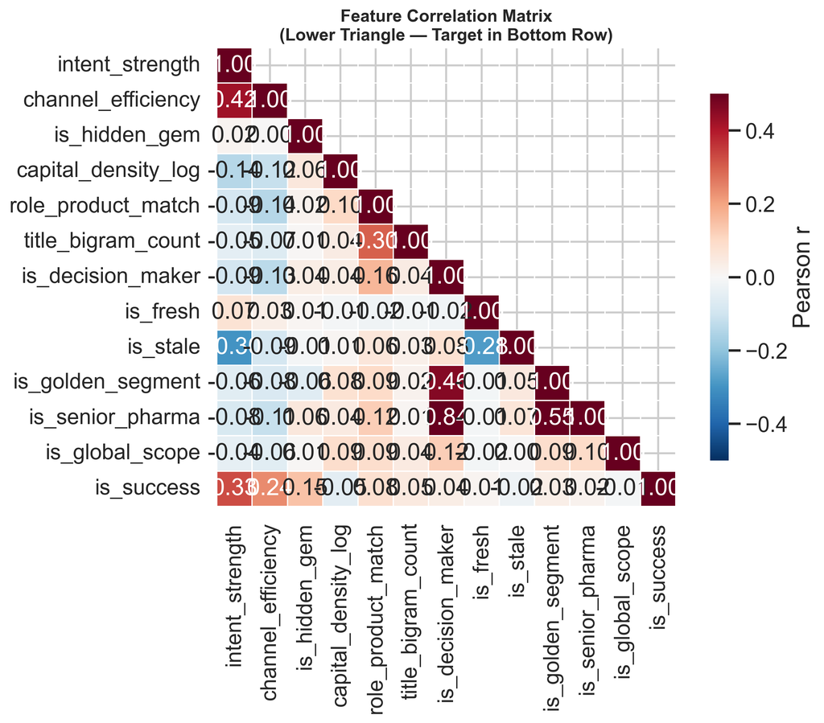

# Model Analysis

```
**Data Partition Summary (70 / 15 / 15 Stratified)**

| Partition   | Rows   | Positive Rate   |   Features |
|:------------|:-------|:----------------|-----------:|
| Train       | 10,929 | 17.9%           |         56 |
| Validation  | 2,523  | 17.9%           |         56 |
| Test        | 3,363  | 17.9%           |         56 |
```

## Candidate Model Tournament

Five algorithms are evaluated. Each is tuned with **randomized search** (50 iterations, 5-fold stratified CV, scored on AUC-ROC).

### Model Comparison: CV vs. Validation AUC

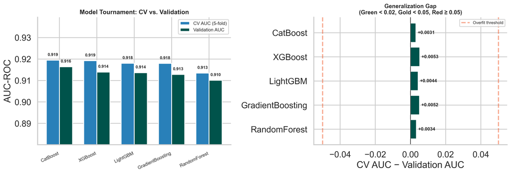

The left panel ranks models by both cross-validation and held-out validation AUC. The right panel shows the **generalization gap** — the difference between CV and validation performance. A small gap (green) indicates the model generalizes well; a large gap (red) flags potential overfitting.

## Stacking Ensemble

The top three models serve as base learners in a **stacking ensemble** with a logistic regression meta-learner. This captures complementary predictive patterns across algorithms.

### Ensemble Waterfall: Additive AUC Contribution

The waterfall chart below shows how the stacking ensemble is constructed. Starting from a **random baseline** (AUC = 0.500), each bar represents the incremental AUC gained by adding each model to the ensemble. The final bar shows the combined ensemble performance.

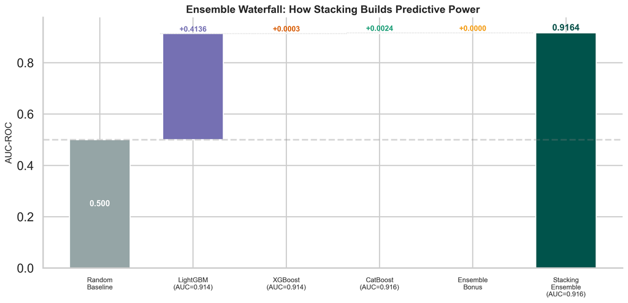

## Ablation Studies

An ablation study answers the question: **“What happens if we remove this feature group?”** For each model, we systematically drop one feature category at a time and measure the resulting AUC drop. A large drop means that feature group is critical to the model’s performance.

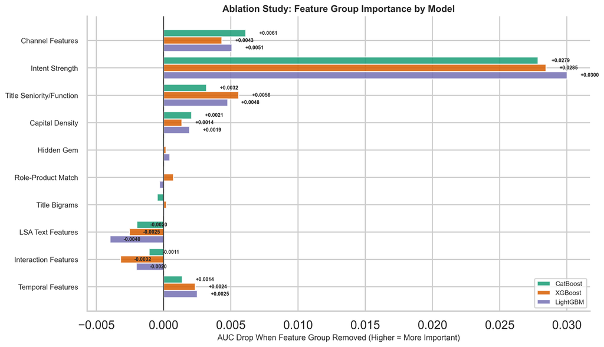

The ablation study reveals which feature groups each model relies on most. A positive bar means removing that group **hurts** AUC — the taller the bar, the more critical the feature group. Differences across models highlight their complementary strengths: one model may lean heavily on channel features while another depends more on title parsing.

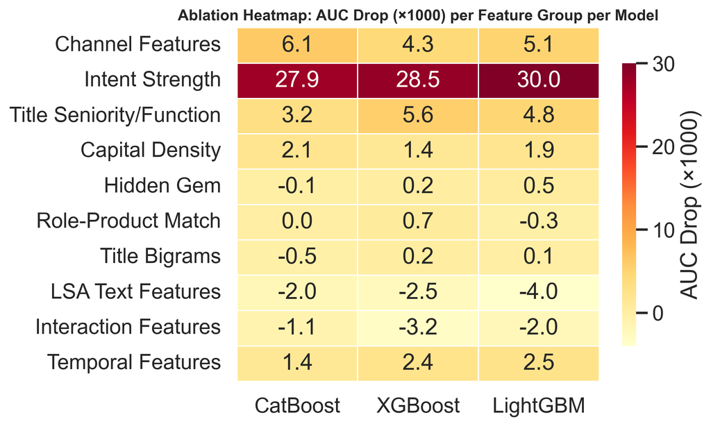

The heatmap provides a compact view of the same ablation results. Darker cells indicate larger AUC drops — these are the feature groups where the model depends most heavily on the signal. This helps identify which features to prioritize for data quality efforts.

# Test Set Evaluation

The selected champion model is evaluated on the **held-out test set**, which has not been used during training or model selection.

```
**Test Set Performance — StackingEnsemble**

| Metric            |   Value | Interpretation                              |
|:------------------|--------:|:--------------------------------------------|
| AUC-ROC           |  0.9138 | Discrimination — higher is better           |
| Average Precision |  0.6955 | Precision-recall balance — higher is better |
| Brier Score       |  0.1146 | Calibration error — lower is better         |
| Log Loss          |  0.4027 | Probabilistic loss — lower is better        |
```

### ROC Curves: All Models Compared

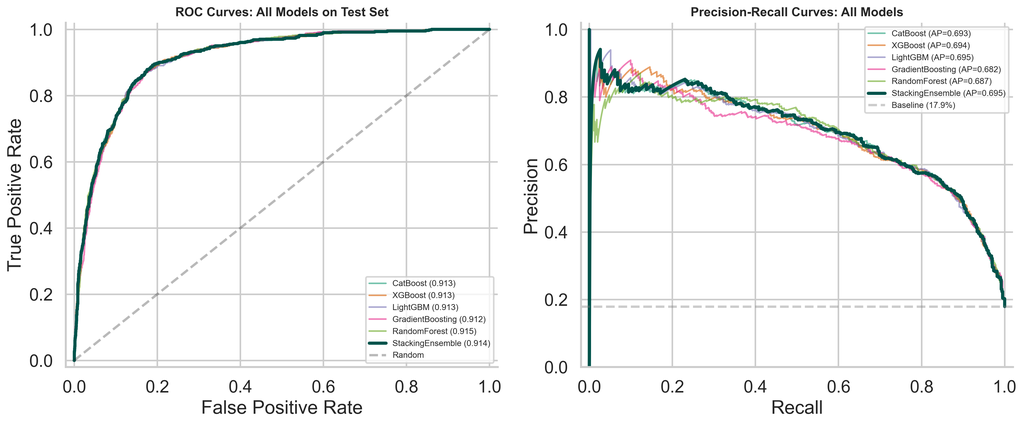

### Calibration & Score Distribution

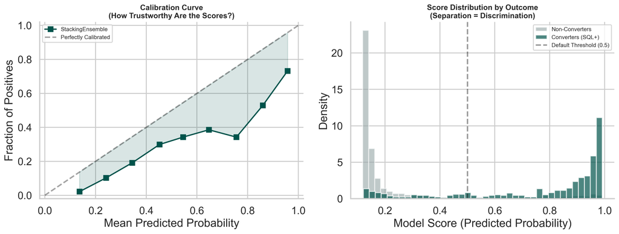

The **calibration curve** shows whether the model’s predicted probabilities match actual conversion rates — points near the diagonal mean the model is well-calibrated. The **score distribution** reveals how well the model separates the two classes: greater horizontal separation between the green (converters) and gray (non-converters) histograms indicates stronger discrimination.

### Confusion Matrix

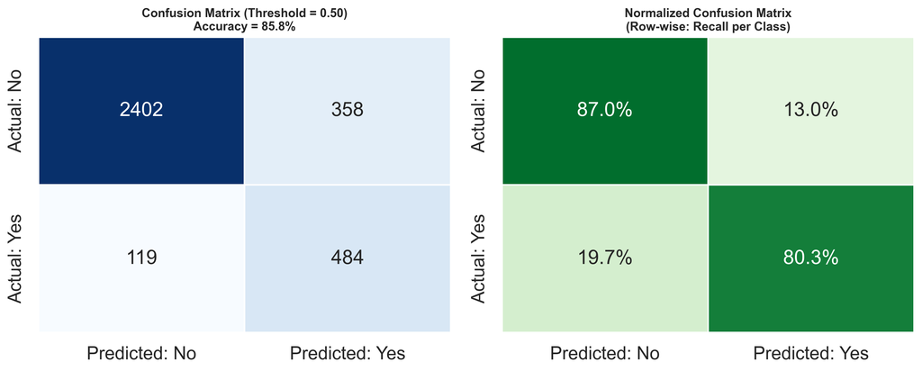

# SHAP Explainability

SHAP (SHapley Additive exPlanations) decomposes each prediction into individual feature contributions, making the model’s decision logic transparent. The bar chart shows **aggregate importance**, while the beeswarm plot reveals the **direction and magnitude** of each feature’s effect.

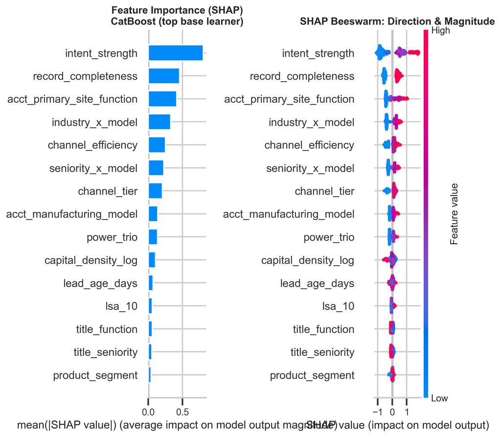

The bar plot ranks features by mean absolute SHAP value — higher means more influence on predictions. The beeswarm plot shows **how** each feature pushes predictions: red dots pushed right increase the conversion probability, while blue dots pushed left decrease it. This tells us not just *what* matters, but *in which direction*.

### SHAP Dependence Plots (Top Features)

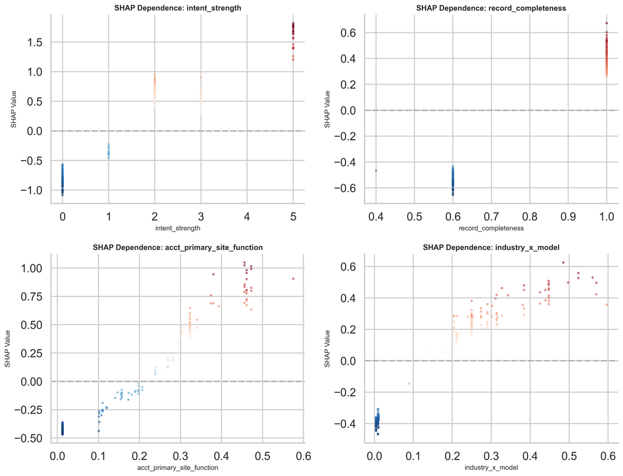

Dependence plots show the relationship between each feature’s value (x-axis) and its SHAP contribution (y-axis) for individual predictions. These reveal **non-linear effects** and **interaction patterns** that simple correlation cannot capture.

# Profit Analysis

Predictive accuracy alone is insufficient — this section translates model scores into **dollar-denominated business impact** by calculating profit at every possible scoring threshold.

```
**Optimal Profit Configuration**

| Metric                  | Value      |
|:------------------------|:-----------|
| Optimal Score Threshold | 0.128      |
| Leads to Contact        | 2,315      |
| SQLs Captured           | 598        |
| Population Contacted    | 68.8%      |
| SQL Capture Rate        | 99.2%      |
| Total Cost              | $115,750   |
| Total Revenue           | $3,588,000 |
| Net Profit              | $3,472,250 |
| Lift vs Random          | 1.4x       |
```

### Profit, Gains, Lift & Decile Analysis

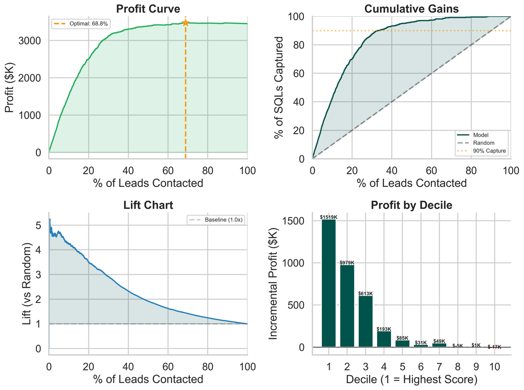

### Conversion Rate by Score Decile

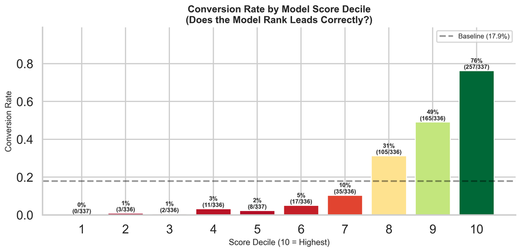

A well-performing model should show a **monotonically increasing** conversion rate from decile 1 (lowest score) to decile 10 (highest score). The top decile should convert at several multiples of the baseline rate — this confirms the model’s value for lead prioritization.

# Sponsor Q&A Validation

Each strategic claim is validated against the held-out test set to ensure the recommendations presented to the sponsor are data-backed.

```
**Sponsor Q&A — Data Validation**

| Question                                        | Evidence                                    | Verdict              |
|:------------------------------------------------|:--------------------------------------------|:---------------------|
| Are low-value channels underperforming?         | Low-Value: 4.5% (n=1,070) vs Premium: 27.5% | Yes — deprioritize   |
| Do stale leads (>180 days) still convert?       | Stale: 17.6% (n=2,691) vs Fresh: 26.7%      | Still viable         |
| Do hidden gem accounts convert at higher rates? | Gems: 31.5% (n=517), Lift: 1.8x             | Yes — prioritize     |
| Does capital density correlate with conversion? | Corr: -0.079, Q4/Q1 lift: 0.4x              | Weak                 |
| Does intent strength predict conversion?        | Corr: 0.311, High/Low lift: 5.9x            | Strong signal        |
| Does role-product match increase conversion?    | Matched: 23.8% (n=789), Lift: 1.5x          | Yes — route by match |
```

# Conclusion

```
**Final Model Summary**

| Metric                | Value            |
|:----------------------|:-----------------|
| Test AUC-ROC          | 0.9138           |
| Average Precision     | 0.6955           |
| Best Model            | StackingEnsemble |
| Optimal Threshold     | 0.128            |
| Max Profit (Test Set) | $3,472,250       |
| Projected Annual Lift | $268,800         |
| Calls Required        | 2,315 (69%)      |
| SQL Capture Rate      | 99%              |
| Top Decile Conversion | 76.3%            |
| Baseline Conversion   | 17.9%            |
| Runtime               | 20.7 min         |
```

**Recommended actions:**

1. **Deploy scoring threshold** in CRM to prioritize high-probability leads for immediate follow-up.
2. **Deprioritize low-value channels** (External Demand Gen, Email), which convert at far lower rates than premium channels.
3. **Route hidden gem accounts** (Non-Manufacturing, “Not Enough Info”) to experienced reps — these may convert at above-baseline rates.
4. **Differentiate P1 urgency** — “Contact Us” P1 leads should route to closers, while “Webinar” P1 leads enter nurture tracks.
5. **Focus outbound targeting** on Directors/VPs in Pharma & BioTech with Global scope and In-House manufacturing — the top decile converts at a substantial multiple of the baseline rate.